# Programming with models (2): Inspecting model structure

NIMBLE training materials module

NIMBLE Development Team

# Running example: the pump model

We first need to build the model.

```r
pumpCode <- nimbleCode({
  for (i in 1:N){

      # likelihood (data model)
      x[i] ~ dpois(lambda[i])

      # latent process (random effects)
      # linear predictor
      lambda[i] <- theta[i]*t[i]
      # random effects distribution
      theta[i] ~ dgamma(alpha,beta)
  }
  # priors on hyperparameters
  alpha ~ dexp(1.0)
  beta ~ dgamma(0.1,1.0)
})
```

```r
N <- 10
t <- c(94.3, 15.7, 62.9, 126, 5.24, 31.4, 1.05, 1.05, 2.1, 10.5)
x <- c(5, 1, 5, 14, 3, 19, 1, 1, 4, 22)
pumpConsts <- list(t = t, N = 10)
pumpData <- list(x = x)
pumpInits <- list(alpha = 1, beta = 1,
         theta = rep(0.1, pumpConsts$N))
pump <- nimbleModel(pumpCode,
          data = pumpData, constants = pumpConsts, inits = pumpInits)
```

```
## defining model...
```

```
## building model...
```

```
## setting data and initial values...
```

```
## checking model...   (use nimbleModel(..., check = FALSE) to skip model check)
```

```
## model building finished
```

```r
Cpump <- compileNimble(pump)
```

# Nodes and variables

The parameters and data in a model are represented as nodes in a graph. Here we define some terms:

- parameter: an unknown quantity in the model that is represented as a random variable and will generally be estimated in an algorithm, e.g. `alpha` in the pump model
- data: a known quantity in a model, also represented as a random variable, e.g., `x[1], x[2], ...` in the pump model
- constants: other fixed quantities involved in the model, e.g., `N` in the pump model
- node: an element in the model representing data, parameter, or a deterministic quantity that is a function of other quantities in the model, e.g., `alpha` or `x[3]` in the pump model
- variable: a collection of one or more nodes with the same name, e.g., `alpha` or `x` in the pump model

# Inspecting the model: nodes

NIMBLE provides users and programmers with the ability to get information about the nodes and variables in the model and the relationships amongst them.

What are the nodes in the model? What are the dependencies of a given node (this is information used in many algorithms)?

```r
pump$getNodeNames()
```

```
##  [1] "alpha"               "beta"                "lifted_d1_over_beta"
##  [4] "theta[1]"            "theta[2]"            "theta[3]"
##  [7] "theta[4]"            "theta[5]"            "theta[6]"
## [10] "theta[7]"            "theta[8]"            "theta[9]"
## [13] "theta[10]"           "lambda[1]"           "lambda[2]"
## [16] "lambda[3]"           "lambda[4]"           "lambda[5]"
## [19] "lambda[6]"           "lambda[7]"           "lambda[8]"
## [22] "lambda[9]"           "lambda[10]"          "x[1]"
## [25] "x[2]"                "x[3]"                "x[4]"
## [28] "x[5]"                "x[6]"                "x[7]"
## [31] "x[8]"                "x[9]"                "x[10]"
```

```r
hypers <- pump$getNodeNames(topOnly = TRUE)
hypers
```

```
## [1] "alpha" "beta"
```

```r
pump$getDependencies(hypers)
```

```
##  [1] "alpha"               "beta"                "lifted_d1_over_beta"
##  [4] "theta[1]"            "theta[2]"            "theta[3]"
##  [7] "theta[4]"            "theta[5]"            "theta[6]"
## [10] "theta[7]"            "theta[8]"            "theta[9]"
## [13] "theta[10]"
```

There are a variety of options to `getNodeNames()` and `getDependencies` that allow you to fine-tune the information you get.

```r
args(pump$getDependencies)
```

```
## function (nodes, omit = character(), self = TRUE, determOnly = FALSE,
##     stochOnly = FALSE, includeData = TRUE, dataOnly = FALSE,
##     includeRHSonly = FALSE, downstream = FALSE, returnType = "names",
##     returnScalarComponents = FALSE)
## NULL
```

```r
args(pump$getNodeNames)
```

```
## function (determOnly = FALSE, stochOnly = FALSE, includeData = TRUE,
##     dataOnly = FALSE, includeRHSonly = FALSE, topOnly = FALSE,
##     latentOnly = FALSE, endOnly = FALSE, returnType = "names",
##     returnScalarComponents = FALSE)
## NULL
```

```r
latents <- pump$getNodeNames(latentOnly = TRUE, stochOnly = TRUE)
latents
```

```
##  [1] "theta[1]"  "theta[2]"  "theta[3]"  "theta[4]"  "theta[5]"
##  [6] "theta[6]"  "theta[7]"  "theta[8]"  "theta[9]"  "theta[10]"
```

```r
pump$getDependencies(latents, determOnly = TRUE)
```

```
##  [1] "lambda[1]"  "lambda[2]"  "lambda[3]"  "lambda[4]"  "lambda[5]"
##  [6] "lambda[6]"  "lambda[7]"  "lambda[8]"  "lambda[9]"  "lambda[10]"
```

```r
pump$getNodeNames(dataOnly = TRUE)
```

```
##  [1] "x[1]"  "x[2]"  "x[3]"  "x[4]"  "x[5]"  "x[6]"  "x[7]"  "x[8]"
##  [9] "x[9]"  "x[10]"
```

# Inspecting the model: variables

What are the variables in the model? What information is available about them?

```r
pump$getVarNames()
```

```
## [1] "x"                   "lambda"              "lifted_d1_over_beta"
## [4] "theta"               "alpha"               "beta"
```

```r
pump$getVarInfo('theta')
```

```
## Reference class object of class "varInfoClass"
## Field "varName":
## [1] "theta"
## Field "mins":
## [1] 1
## Field "maxs":
## [1] 10
## Field "nDim":
## [1] 1
## Field "anyStoch":
## [1] TRUE
```

As of the current version of NIMBLE, information about variables is not competely nicely arranged for a user (there aren’t as many query functions), but it is available.

This variable has 1 dimension (`nDim`), and its size is 10 (`maxs`). Currently `mins` is always 1. If at least one node within the variable is stochastic, then `anyStoch` will be `TRUE`.

# The importance of querying a model: lifted nodes

You may have noticed a strangely-named node, *lifted_d1_over_beta*, in the pump model. NIMBLE implements some features by inserting its own nodes. *You should never assume you know what nodes are in a model simply because you wrote the BUGS code.*

Let’s look at the two main ways this happens:

```r
m1 <- nimbleModel(
    nimbleCode({
        tau ~ dunif(0, 100)
        x ~ dnorm(0, tau) #by default, tau is a precision
    }))
```

```
## defining model...
```

```
## building model...
```

```
## checking model...   (use nimbleModel(..., check = FALSE) to skip model check)
```

```
## NAs were detected in model variables: tau, logProb_tau, lifted_d1_over_sqrt_oPtau_cP, x, logProb_x.
```

```
## model building finished
```

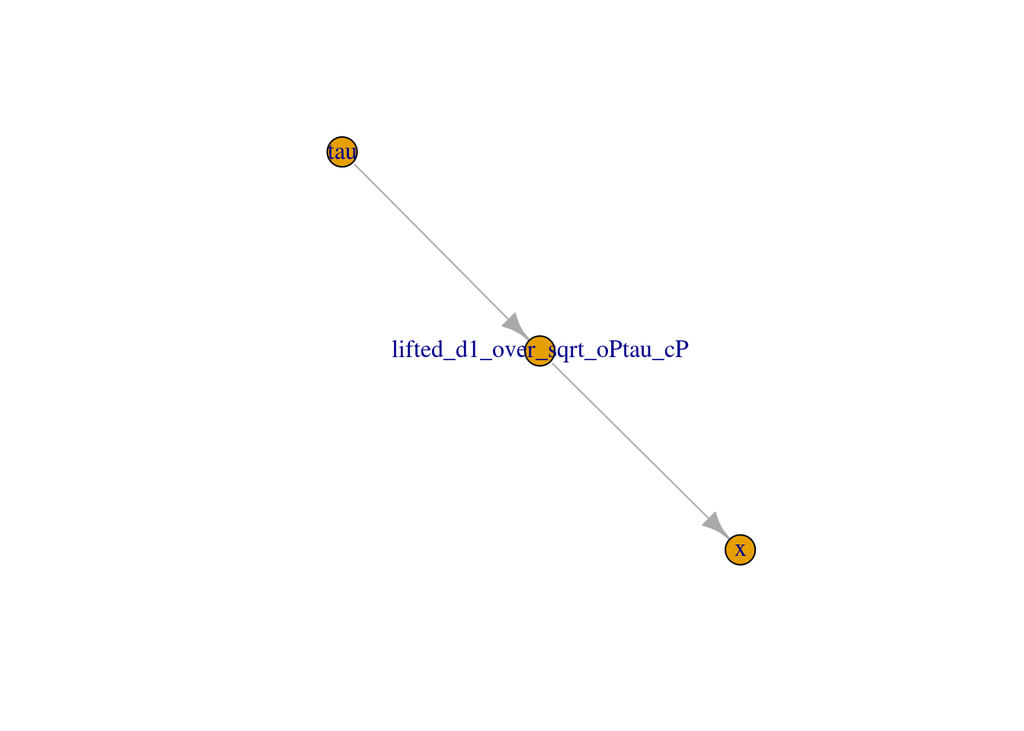

```r
plot(m1$getGraph())
```

```r
m1$getNodeNames()
```

```
## [1] "tau"                          "lifted_d1_over_sqrt_oPtau_cP"
## [3] "x"
```

The node `lifted_d1_over_sqrt_oPtau_cP` has been inserted between `tau` and `x`. The resulting model would equivalently have been created by this BUGS code:

```r
nimbleCode({
    tau ~ dunif(0, 100)
    lifted_d1_over_sqrt_oPtau_cP <- 1/sqrt(tau)
    x ~ dnorm(0, sd = lifted_d1_over_sqrt_oPtau_cP) #by default, tau is a precision
}))
```

NIMBLE has *lifted* the calculation of standard deviation from precision so that it is part of the model’s graph. Therefore *you will make a mistake if you assume that the dependencies of `tau` include only `x`*:

```r
m1$tau <- 3
m1$x <- 1
m1$calculate(c('tau','x')) ## Wrong: the lifted node is being neglected
```

```
## [1] NA
```

The correct way to do this is with model-generic programming:

```r
m1$getDependencies('tau')
```

```
## [1] "tau"                          "lifted_d1_over_sqrt_oPtau_cP"
## [3] "x"
```

```r
m1$calculate( m1$getDependencies('tau') )
```

```
## [1] -6.474803
```

The second common situation that creates lifted nodes is:

```r
m2 <- nimbleModel(
    nimbleCode({
        a ~ dnorm(0, 1)
        b ~ dnorm(a + 1, 1)
    }))
```

```
## defining model...
```

```
## building model...
```

```
## checking model...   (use nimbleModel(..., check = FALSE) to skip model check)
```

```
## NAs were detected in model variables: a, logProb_a, lifted_a_plus_1, b, logProb_b.
```

```
## model building finished
```

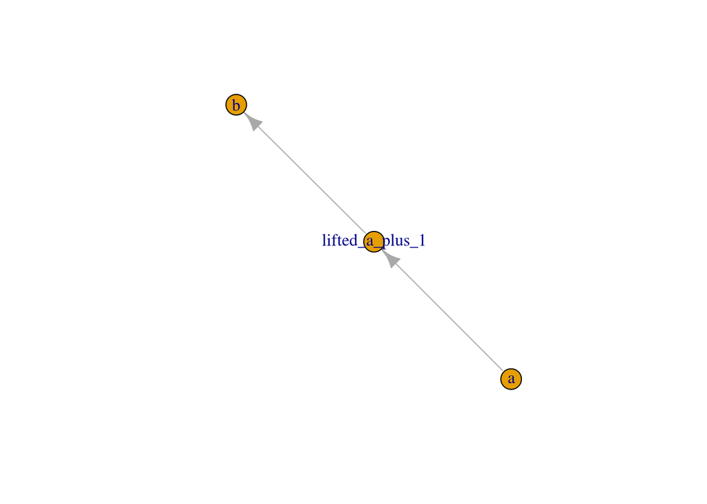

```r
plot(m2$getGraph())
```

```r
m2$getNodeNames()
```

```
## [1] "a"               "lifted_a_plus_1" "b"
```

In this case, NIMBLE lifted the expression `a+1` and created a node for it. Again the correct way to program is to query a model to learn about its nodes. Do not assume you know what the nodes are.